# Risk Factor Analysis

## Outcome Variable

**Outcome Variable:** stunted

## Predictor Variables

**Intervention Variable:** month

**Adjustment Set:**

unadjusted

## Stratifying Variables

The analysis was stratified on these variable(s):

- agecat
- studyid
- country

## Data Summary

| agecat | studyid | country | A | n | nA | nAY0 | nAY1 |
| --- | --- | --- | --- | --- | --- | --- | --- |
| Birth | ki0047075b-MAL-ED | BANGLADESH | 1 | 257 | 19 | 16 | 3 |
| Birth | ki0047075b-MAL-ED | BANGLADESH | 2 | 257 | 24 | 18 | 6 |
| Birth | ki0047075b-MAL-ED | BANGLADESH | 3 | 257 | 28 | 20 | 8 |
| Birth | ki0047075b-MAL-ED | BANGLADESH | 4 | 257 | 21 | 21 | 0 |
| Birth | ki0047075b-MAL-ED | BANGLADESH | 5 | 257 | 21 | 16 | 5 |
| Birth | ki0047075b-MAL-ED | BANGLADESH | 6 | 257 | 9 | 5 | 4 |
| Birth | ki0047075b-MAL-ED | BANGLADESH | 7 | 257 | 22 | 17 | 5 |
| Birth | ki0047075b-MAL-ED | BANGLADESH | 8 | 257 | 25 | 20 | 5 |
| Birth | ki0047075b-MAL-ED | BANGLADESH | 9 | 257 | 22 | 20 | 2 |
| Birth | ki0047075b-MAL-ED | BANGLADESH | 10 | 257 | 24 | 19 | 5 |
| Birth | ki0047075b-MAL-ED | BANGLADESH | 11 | 257 | 15 | 13 | 2 |
| Birth | ki0047075b-MAL-ED | BANGLADESH | 12 | 257 | 27 | 25 | 2 |
| Birth | ki0047075b-MAL-ED | BRAZIL | 1 | 191 | 9 | 9 | 0 |
| Birth | ki0047075b-MAL-ED | BRAZIL | 2 | 191 | 21 | 18 | 3 |
| Birth | ki0047075b-MAL-ED | BRAZIL | 3 | 191 | 18 | 17 | 1 |
| Birth | ki0047075b-MAL-ED | BRAZIL | 4 | 191 | 8 | 8 | 0 |
| Birth | ki0047075b-MAL-ED | BRAZIL | 5 | 191 | 19 | 16 | 3 |
| Birth | ki0047075b-MAL-ED | BRAZIL | 6 | 191 | 7 | 6 | 1 |
| Birth | ki0047075b-MAL-ED | BRAZIL | 7 | 191 | 17 | 13 | 4 |
| Birth | ki0047075b-MAL-ED | BRAZIL | 8 | 191 | 18 | 16 | 2 |
| Birth | ki0047075b-MAL-ED | BRAZIL | 9 | 191 | 28 | 24 | 4 |
| Birth | ki0047075b-MAL-ED | BRAZIL | 10 | 191 | 18 | 18 | 0 |
| Birth | ki0047075b-MAL-ED | BRAZIL | 11 | 191 | 15 | 15 | 0 |
| Birth | ki0047075b-MAL-ED | BRAZIL | 12 | 191 | 13 | 10 | 3 |
| Birth | ki0047075b-MAL-ED | INDIA | 1 | 206 | 16 | 15 | 1 |
| Birth | ki0047075b-MAL-ED | INDIA | 2 | 206 | 16 | 16 | 0 |
| Birth | ki0047075b-MAL-ED | INDIA | 3 | 206 | 20 | 18 | 2 |
| Birth | ki0047075b-MAL-ED | INDIA | 4 | 206 | 15 | 13 | 2 |
| Birth | ki0047075b-MAL-ED | INDIA | 5 | 206 | 7 | 6 | 1 |
| Birth | ki0047075b-MAL-ED | INDIA | 6 | 206 | 17 | 16 | 1 |

[output cut: 1746 more lines]

The following strata were considered:

- agecat: 12 months, studyid: ki0047075b-MAL-ED, country: BANGLADESH
- agecat: 12 months, studyid: ki0047075b-MAL-ED, country: BRAZIL
- agecat: 12 months, studyid: ki0047075b-MAL-ED, country: INDIA
- agecat: 12 months, studyid: ki0047075b-MAL-ED, country: NEPAL
- agecat: 12 months, studyid: ki0047075b-MAL-ED, country: PERU
- agecat: 12 months, studyid: ki0047075b-MAL-ED, country: SOUTH AFRICA
- agecat: 12 months, studyid: ki0047075b-MAL-ED, country: TANZANIA, UNITED REPUBLIC OF
- agecat: 12 months, studyid: ki1000108-CMC-V-BCS-2002, country: INDIA
- agecat: 12 months, studyid: ki1000108-IRC, country: INDIA
- agecat: 12 months, studyid: ki1000109-EE, country: PAKISTAN
- agecat: 12 months, studyid: ki1000109-ResPak, country: PAKISTAN
- agecat: 12 months, studyid: ki1000304b-SAS-FoodSuppl, country: INDIA
- agecat: 12 months, studyid: ki1017093-NIH-Birth, country: BANGLADESH
- agecat: 12 months, studyid: ki1066203-TanzaniaChild2, country: TANZANIA, UNITED REPUBLIC OF
- agecat: 12 months, studyid: ki1112895-Guatemala BSC, country: GUATEMALA
- agecat: 12 months, studyid: ki1113344-GMS-Nepal, country: NEPAL
- agecat: 12 months, studyid: ki1114097-CMIN, country: BANGLADESH
- agecat: 12 months, studyid: ki1114097-CMIN, country: BRAZIL
- agecat: 12 months, studyid: ki1114097-CMIN, country: GUINEA-BISSAU
- agecat: 12 months, studyid: ki1114097-CMIN, country: PERU
- agecat: 12 months, studyid: ki1114097-CONTENT, country: PERU
- agecat: 12 months, studyid: ki1126311-ZVITAMBO, country: ZIMBABWE
- agecat: 12 months, studyid: ki1148112-LCNI-5, country: MALAWI
- agecat: 18 months, studyid: ki0047075b-MAL-ED, country: BANGLADESH
- agecat: 18 months, studyid: ki0047075b-MAL-ED, country: BRAZIL
- agecat: 18 months, studyid: ki0047075b-MAL-ED, country: INDIA
- agecat: 18 months, studyid: ki0047075b-MAL-ED, country: NEPAL
- agecat: 18 months, studyid: ki0047075b-MAL-ED, country: PERU
- agecat: 18 months, studyid: ki0047075b-MAL-ED, country: SOUTH AFRICA
- agecat: 18 months, studyid: ki0047075b-MAL-ED, country: TANZANIA, UNITED REPUBLIC OF
- agecat: 18 months, studyid: ki1000108-CMC-V-BCS-2002, country: INDIA
- agecat: 18 months, studyid: ki1000108-IRC, country: INDIA
- agecat: 18 months, studyid: ki1000109-EE, country: PAKISTAN
- agecat: 18 months, studyid: ki1000109-ResPak, country: PAKISTAN
- agecat: 18 months, studyid: ki1000304b-SAS-FoodSuppl, country: INDIA
- agecat: 18 months, studyid: ki1017093-NIH-Birth, country: BANGLADESH
- agecat: 18 months, studyid: ki1066203-TanzaniaChild2, country: TANZANIA, UNITED REPUBLIC OF
- agecat: 18 months, studyid: ki1113344-GMS-Nepal, country: NEPAL
- agecat: 18 months, studyid: ki1114097-CMIN, country: BANGLADESH
- agecat: 18 months, studyid: ki1114097-CMIN, country: BRAZIL
- agecat: 18 months, studyid: ki1114097-CMIN, country: GUINEA-BISSAU
- agecat: 18 months, studyid: ki1114097-CMIN, country: PERU
- agecat: 18 months, studyid: ki1114097-CONTENT, country: PERU
- agecat: 18 months, studyid: ki1126311-ZVITAMBO, country: ZIMBABWE
- agecat: 18 months, studyid: ki1148112-LCNI-5, country: MALAWI
- agecat: 24 months, studyid: ki0047075b-MAL-ED, country: BANGLADESH
- agecat: 24 months, studyid: ki0047075b-MAL-ED, country: BRAZIL
- agecat: 24 months, studyid: ki0047075b-MAL-ED, country: INDIA
- agecat: 24 months, studyid: ki0047075b-MAL-ED, country: NEPAL
- agecat: 24 months, studyid: ki0047075b-MAL-ED, country: PERU
- agecat: 24 months, studyid: ki0047075b-MAL-ED, country: SOUTH AFRICA
- agecat: 24 months, studyid: ki0047075b-MAL-ED, country: TANZANIA, UNITED REPUBLIC OF
- agecat: 24 months, studyid: ki1000108-CMC-V-BCS-2002, country: INDIA
- agecat: 24 months, studyid: ki1000108-IRC, country: INDIA
- agecat: 24 months, studyid: ki1017093-NIH-Birth, country: BANGLADESH
- agecat: 24 months, studyid: ki1066203-TanzaniaChild2, country: TANZANIA, UNITED REPUBLIC OF
- agecat: 24 months, studyid: ki1113344-GMS-Nepal, country: NEPAL
- agecat: 24 months, studyid: ki1114097-CMIN, country: BANGLADESH
- agecat: 24 months, studyid: ki1114097-CMIN, country: GUINEA-BISSAU
- agecat: 24 months, studyid: ki1114097-CMIN, country: PERU
- agecat: 24 months, studyid: ki1114097-CONTENT, country: PERU
- agecat: 24 months, studyid: ki1126311-ZVITAMBO, country: ZIMBABWE
- agecat: 24 months, studyid: ki1148112-LCNI-5, country: MALAWI
- agecat: 3 months, studyid: ki0047075b-MAL-ED, country: BANGLADESH
- agecat: 3 months, studyid: ki0047075b-MAL-ED, country: BRAZIL
- agecat: 3 months, studyid: ki0047075b-MAL-ED, country: INDIA
- agecat: 3 months, studyid: ki0047075b-MAL-ED, country: NEPAL
- agecat: 3 months, studyid: ki0047075b-MAL-ED, country: PERU
- agecat: 3 months, studyid: ki0047075b-MAL-ED, country: SOUTH AFRICA
- agecat: 3 months, studyid: ki0047075b-MAL-ED, country: TANZANIA, UNITED REPUBLIC OF
- agecat: 3 months, studyid: ki1000108-CMC-V-BCS-2002, country: INDIA
- agecat: 3 months, studyid: ki1000108-IRC, country: INDIA
- agecat: 3 months, studyid: ki1000109-EE, country: PAKISTAN
- agecat: 3 months, studyid: ki1000109-ResPak, country: PAKISTAN
- agecat: 3 months, studyid: ki1000304b-SAS-FoodSuppl, country: INDIA
- agecat: 3 months, studyid: ki1017093-NIH-Birth, country: BANGLADESH
- agecat: 3 months, studyid: ki1066203-TanzaniaChild2, country: TANZANIA, UNITED REPUBLIC OF
- agecat: 3 months, studyid: ki1112895-Guatemala BSC, country: GUATEMALA
- agecat: 3 months, studyid: ki1113344-GMS-Nepal, country: NEPAL
- agecat: 3 months, studyid: ki1114097-CMIN, country: BANGLADESH
- agecat: 3 months, studyid: ki1114097-CMIN, country: BRAZIL
- agecat: 3 months, studyid: ki1114097-CMIN, country: GUINEA-BISSAU
- agecat: 3 months, studyid: ki1114097-CMIN, country: PERU
- agecat: 3 months, studyid: ki1114097-CONTENT, country: PERU
- agecat: 3 months, studyid: ki1126311-ZVITAMBO, country: ZIMBABWE
- agecat: 6 months, studyid: ki0047075b-MAL-ED, country: BANGLADESH
- agecat: 6 months, studyid: ki0047075b-MAL-ED, country: BRAZIL
- agecat: 6 months, studyid: ki0047075b-MAL-ED, country: INDIA
- agecat: 6 months, studyid: ki0047075b-MAL-ED, country: NEPAL
- agecat: 6 months, studyid: ki0047075b-MAL-ED, country: PERU
- agecat: 6 months, studyid: ki0047075b-MAL-ED, country: SOUTH AFRICA
- agecat: 6 months, studyid: ki0047075b-MAL-ED, country: TANZANIA, UNITED REPUBLIC OF
- agecat: 6 months, studyid: ki1000108-CMC-V-BCS-2002, country: INDIA
- agecat: 6 months, studyid: ki1000108-IRC, country: INDIA
- agecat: 6 months, studyid: ki1000109-EE, country: PAKISTAN
- agecat: 6 months, studyid: ki1000109-ResPak, country: PAKISTAN
- agecat: 6 months, studyid: ki1000304b-SAS-FoodSuppl, country: INDIA
- agecat: 6 months, studyid: ki1017093-NIH-Birth, country: BANGLADESH
- agecat: 6 months, studyid: ki1066203-TanzaniaChild2, country: TANZANIA, UNITED REPUBLIC OF
- agecat: 6 months, studyid: ki1112895-Guatemala BSC, country: GUATEMALA
- agecat: 6 months, studyid: ki1113344-GMS-Nepal, country: NEPAL
- agecat: 6 months, studyid: ki1114097-CMIN, country: BANGLADESH
- agecat: 6 months, studyid: ki1114097-CMIN, country: BRAZIL
- agecat: 6 months, studyid: ki1114097-CMIN, country: GUINEA-BISSAU
- agecat: 6 months, studyid: ki1114097-CMIN, country: PERU
- agecat: 6 months, studyid: ki1114097-CONTENT, country: PERU
- agecat: 6 months, studyid: ki1126311-ZVITAMBO, country: ZIMBABWE
- agecat: 6 months, studyid: ki1148112-LCNI-5, country: MALAWI
- agecat: 9 months, studyid: ki0047075b-MAL-ED, country: BANGLADESH
- agecat: 9 months, studyid: ki0047075b-MAL-ED, country: BRAZIL
- agecat: 9 months, studyid: ki0047075b-MAL-ED, country: INDIA
- agecat: 9 months, studyid: ki0047075b-MAL-ED, country: NEPAL
- agecat: 9 months, studyid: ki0047075b-MAL-ED, country: PERU
- agecat: 9 months, studyid: ki0047075b-MAL-ED, country: SOUTH AFRICA
- agecat: 9 months, studyid: ki0047075b-MAL-ED, country: TANZANIA, UNITED REPUBLIC OF
- agecat: 9 months, studyid: ki1000108-CMC-V-BCS-2002, country: INDIA
- agecat: 9 months, studyid: ki1000108-IRC, country: INDIA
- agecat: 9 months, studyid: ki1000109-EE, country: PAKISTAN
- agecat: 9 months, studyid: ki1000109-ResPak, country: PAKISTAN
- agecat: 9 months, studyid: ki1000304b-SAS-FoodSuppl, country: INDIA
- agecat: 9 months, studyid: ki1017093-NIH-Birth, country: BANGLADESH
- agecat: 9 months, studyid: ki1066203-TanzaniaChild2, country: TANZANIA, UNITED REPUBLIC OF
- agecat: 9 months, studyid: ki1112895-Guatemala BSC, country: GUATEMALA
- agecat: 9 months, studyid: ki1113344-GMS-Nepal, country: NEPAL
- agecat: 9 months, studyid: ki1114097-CMIN, country: BANGLADESH
- agecat: 9 months, studyid: ki1114097-CMIN, country: BRAZIL
- agecat: 9 months, studyid: ki1114097-CMIN, country: GUINEA-BISSAU
- agecat: 9 months, studyid: ki1114097-CMIN, country: PERU
- agecat: 9 months, studyid: ki1114097-CONTENT, country: PERU
- agecat: 9 months, studyid: ki1126311-ZVITAMBO, country: ZIMBABWE
- agecat: 9 months, studyid: ki1148112-LCNI-5, country: MALAWI
- agecat: Birth, studyid: ki0047075b-MAL-ED, country: BANGLADESH
- agecat: Birth, studyid: ki0047075b-MAL-ED, country: BRAZIL
- agecat: Birth, studyid: ki0047075b-MAL-ED, country: INDIA
- agecat: Birth, studyid: ki0047075b-MAL-ED, country: NEPAL
- agecat: Birth, studyid: ki0047075b-MAL-ED, country: PERU
- agecat: Birth, studyid: ki0047075b-MAL-ED, country: SOUTH AFRICA
- agecat: Birth, studyid: ki0047075b-MAL-ED, country: TANZANIA, UNITED REPUBLIC OF
- agecat: Birth, studyid: ki1000108-CMC-V-BCS-2002, country: INDIA
- agecat: Birth, studyid: ki1000108-IRC, country: INDIA
- agecat: Birth, studyid: ki1000109-EE, country: PAKISTAN
- agecat: Birth, studyid: ki1000109-ResPak, country: PAKISTAN
- agecat: Birth, studyid: ki1017093-NIH-Birth, country: BANGLADESH
- agecat: Birth, studyid: ki1114097-CMIN, country: BANGLADESH
- agecat: Birth, studyid: ki1114097-CMIN, country: BRAZIL
- agecat: Birth, studyid: ki1114097-CMIN, country: PERU
- agecat: Birth, studyid: ki1114097-CONTENT, country: PERU
- agecat: Birth, studyid: ki1126311-ZVITAMBO, country: ZIMBABWE

### Dropped Strata

Some strata were dropped due to rare outcomes:

- agecat: Birth, studyid: ki0047075b-MAL-ED, country: BANGLADESH
- agecat: Birth, studyid: ki0047075b-MAL-ED, country: BRAZIL
- agecat: Birth, studyid: ki0047075b-MAL-ED, country: INDIA
- agecat: Birth, studyid: ki0047075b-MAL-ED, country: NEPAL
- agecat: Birth, studyid: ki0047075b-MAL-ED, country: PERU
- agecat: Birth, studyid: ki0047075b-MAL-ED, country: SOUTH AFRICA
- agecat: Birth, studyid: ki0047075b-MAL-ED, country: TANZANIA, UNITED REPUBLIC OF
- agecat: Birth, studyid: ki1000108-CMC-V-BCS-2002, country: INDIA
- agecat: Birth, studyid: ki1000108-IRC, country: INDIA
- agecat: Birth, studyid: ki1000109-EE, country: PAKISTAN
- agecat: Birth, studyid: ki1000109-ResPak, country: PAKISTAN
- agecat: Birth, studyid: ki1017093-NIH-Birth, country: BANGLADESH
- agecat: Birth, studyid: ki1114097-CMIN, country: BANGLADESH
- agecat: Birth, studyid: ki1114097-CMIN, country: BRAZIL
- agecat: Birth, studyid: ki1114097-CMIN, country: PERU
- agecat: Birth, studyid: ki1114097-CONTENT, country: PERU
- agecat: 3 months, studyid: ki0047075b-MAL-ED, country: BANGLADESH
- agecat: 3 months, studyid: ki0047075b-MAL-ED, country: BRAZIL
- agecat: 3 months, studyid: ki0047075b-MAL-ED, country: INDIA
- agecat: 3 months, studyid: ki0047075b-MAL-ED, country: NEPAL
- agecat: 3 months, studyid: ki0047075b-MAL-ED, country: PERU
- agecat: 3 months, studyid: ki0047075b-MAL-ED, country: SOUTH AFRICA
- agecat: 3 months, studyid: ki0047075b-MAL-ED, country: TANZANIA, UNITED REPUBLIC OF
- agecat: 3 months, studyid: ki1000108-CMC-V-BCS-2002, country: INDIA
- agecat: 3 months, studyid: ki1000108-IRC, country: INDIA
- agecat: 3 months, studyid: ki1000109-EE, country: PAKISTAN
- agecat: 3 months, studyid: ki1000109-ResPak, country: PAKISTAN
- agecat: 3 months, studyid: ki1000304b-SAS-FoodSuppl, country: INDIA
- agecat: 3 months, studyid: ki1112895-Guatemala BSC, country: GUATEMALA
- agecat: 3 months, studyid: ki1113344-GMS-Nepal, country: NEPAL
- agecat: 3 months, studyid: ki1114097-CMIN, country: BANGLADESH
- agecat: 3 months, studyid: ki1114097-CMIN, country: BRAZIL
- agecat: 3 months, studyid: ki1114097-CMIN, country: GUINEA-BISSAU
- agecat: 3 months, studyid: ki1114097-CMIN, country: PERU
- agecat: 3 months, studyid: ki1114097-CONTENT, country: PERU
- agecat: 6 months, studyid: ki0047075b-MAL-ED, country: BANGLADESH
- agecat: 6 months, studyid: ki0047075b-MAL-ED, country: BRAZIL
- agecat: 6 months, studyid: ki0047075b-MAL-ED, country: INDIA
- agecat: 6 months, studyid: ki0047075b-MAL-ED, country: NEPAL
- agecat: 6 months, studyid: ki0047075b-MAL-ED, country: PERU
- agecat: 6 months, studyid: ki0047075b-MAL-ED, country: SOUTH AFRICA
- agecat: 6 months, studyid: ki0047075b-MAL-ED, country: TANZANIA, UNITED REPUBLIC OF
- agecat: 6 months, studyid: ki1000109-EE, country: PAKISTAN
- agecat: 6 months, studyid: ki1000109-ResPak, country: PAKISTAN
- agecat: 6 months, studyid: ki1000304b-SAS-FoodSuppl, country: INDIA
- agecat: 6 months, studyid: ki1112895-Guatemala BSC, country: GUATEMALA
- agecat: 6 months, studyid: ki1113344-GMS-Nepal, country: NEPAL
- agecat: 6 months, studyid: ki1114097-CMIN, country: BANGLADESH
- agecat: 6 months, studyid: ki1114097-CMIN, country: BRAZIL
- agecat: 6 months, studyid: ki1114097-CMIN, country: GUINEA-BISSAU
- agecat: 6 months, studyid: ki1114097-CMIN, country: PERU
- agecat: 6 months, studyid: ki1114097-CONTENT, country: PERU
- agecat: 9 months, studyid: ki0047075b-MAL-ED, country: BANGLADESH
- agecat: 9 months, studyid: ki0047075b-MAL-ED, country: BRAZIL
- agecat: 9 months, studyid: ki0047075b-MAL-ED, country: INDIA
- agecat: 9 months, studyid: ki0047075b-MAL-ED, country: NEPAL
- agecat: 9 months, studyid: ki0047075b-MAL-ED, country: PERU
- agecat: 9 months, studyid: ki0047075b-MAL-ED, country: SOUTH AFRICA
- agecat: 9 months, studyid: ki0047075b-MAL-ED, country: TANZANIA, UNITED REPUBLIC OF
- agecat: 9 months, studyid: ki1000108-CMC-V-BCS-2002, country: INDIA
- agecat: 9 months, studyid: ki1000109-EE, country: PAKISTAN
- agecat: 9 months, studyid: ki1000109-ResPak, country: PAKISTAN
- agecat: 9 months, studyid: ki1000304b-SAS-FoodSuppl, country: INDIA
- agecat: 9 months, studyid: ki1112895-Guatemala BSC, country: GUATEMALA
- agecat: 9 months, studyid: ki1113344-GMS-Nepal, country: NEPAL
- agecat: 9 months, studyid: ki1114097-CMIN, country: BANGLADESH
- agecat: 9 months, studyid: ki1114097-CMIN, country: BRAZIL
- agecat: 9 months, studyid: ki1114097-CMIN, country: GUINEA-BISSAU
- agecat: 9 months, studyid: ki1114097-CMIN, country: PERU
- agecat: 9 months, studyid: ki1114097-CONTENT, country: PERU
- agecat: 9 months, studyid: ki1148112-LCNI-5, country: MALAWI
- agecat: 12 months, studyid: ki0047075b-MAL-ED, country: BANGLADESH
- agecat: 12 months, studyid: ki0047075b-MAL-ED, country: BRAZIL
- agecat: 12 months, studyid: ki0047075b-MAL-ED, country: INDIA
- agecat: 12 months, studyid: ki0047075b-MAL-ED, country: NEPAL
- agecat: 12 months, studyid: ki0047075b-MAL-ED, country: PERU
- agecat: 12 months, studyid: ki0047075b-MAL-ED, country: SOUTH AFRICA
- agecat: 12 months, studyid: ki0047075b-MAL-ED, country: TANZANIA, UNITED REPUBLIC OF
- agecat: 12 months, studyid: ki1000108-CMC-V-BCS-2002, country: INDIA
- agecat: 12 months, studyid: ki1000109-EE, country: PAKISTAN
- agecat: 12 months, studyid: ki1000109-ResPak, country: PAKISTAN
- agecat: 12 months, studyid: ki1000304b-SAS-FoodSuppl, country: INDIA
- agecat: 12 months, studyid: ki1112895-Guatemala BSC, country: GUATEMALA
- agecat: 12 months, studyid: ki1113344-GMS-Nepal, country: NEPAL
- agecat: 12 months, studyid: ki1114097-CMIN, country: BANGLADESH
- agecat: 12 months, studyid: ki1114097-CMIN, country: BRAZIL
- agecat: 12 months, studyid: ki1114097-CONTENT, country: PERU
- agecat: 18 months, studyid: ki0047075b-MAL-ED, country: BANGLADESH
- agecat: 18 months, studyid: ki0047075b-MAL-ED, country: BRAZIL
- agecat: 18 months, studyid: ki0047075b-MAL-ED, country: INDIA
- agecat: 18 months, studyid: ki0047075b-MAL-ED, country: NEPAL
- agecat: 18 months, studyid: ki0047075b-MAL-ED, country: PERU
- agecat: 18 months, studyid: ki0047075b-MAL-ED, country: SOUTH AFRICA
- agecat: 18 months, studyid: ki0047075b-MAL-ED, country: TANZANIA, UNITED REPUBLIC OF
- agecat: 18 months, studyid: ki1000108-CMC-V-BCS-2002, country: INDIA
- agecat: 18 months, studyid: ki1000109-EE, country: PAKISTAN
- agecat: 18 months, studyid: ki1000109-ResPak, country: PAKISTAN
- agecat: 18 months, studyid: ki1000304b-SAS-FoodSuppl, country: INDIA
- agecat: 18 months, studyid: ki1113344-GMS-Nepal, country: NEPAL
- agecat: 18 months, studyid: ki1114097-CMIN, country: BANGLADESH
- agecat: 18 months, studyid: ki1114097-CMIN, country: BRAZIL
- agecat: 18 months, studyid: ki1114097-CONTENT, country: PERU
- agecat: 24 months, studyid: ki0047075b-MAL-ED, country: BANGLADESH
- agecat: 24 months, studyid: ki0047075b-MAL-ED, country: BRAZIL
- agecat: 24 months, studyid: ki0047075b-MAL-ED, country: INDIA
- agecat: 24 months, studyid: ki0047075b-MAL-ED, country: NEPAL
- agecat: 24 months, studyid: ki0047075b-MAL-ED, country: PERU
- agecat: 24 months, studyid: ki0047075b-MAL-ED, country: SOUTH AFRICA
- agecat: 24 months, studyid: ki0047075b-MAL-ED, country: TANZANIA, UNITED REPUBLIC OF
- agecat: 24 months, studyid: ki1000108-CMC-V-BCS-2002, country: INDIA
- agecat: 24 months, studyid: ki1000108-IRC, country: INDIA
- agecat: 24 months, studyid: ki1066203-TanzaniaChild2, country: TANZANIA, UNITED REPUBLIC OF
- agecat: 24 months, studyid: ki1113344-GMS-Nepal, country: NEPAL
- agecat: 24 months, studyid: ki1114097-CMIN, country: BANGLADESH
- agecat: 24 months, studyid: ki1114097-CMIN, country: PERU
- agecat: 24 months, studyid: ki1114097-CONTENT, country: PERU
- agecat: 24 months, studyid: ki1126311-ZVITAMBO, country: ZIMBABWE

## Methods Detail

We’re interested in the causal parameters $E[Y_a]$ for all values of $a \in \mathcal{A}$. These parameters represent the mean outcome if, possibly contrary to fact, we intervened to set all units to have $A=a$. Under the randomization and positivity assumptions, these are identified by the statistical parameters $\psi_a=E_W[E_{Y|A,W}(Y|A=a,W)]$. In addition, we’re interested in the mean of $Y$, $E[Y]$ under no intervention (the observed mean). We will estimate these parameters by using SuperLearner to fit the relevant likelihood factors – $E_{Y|A,W}(Y|A=a,W)$ and $p(A=a|W)$, and then updating our likelihood fit using a joint TMLE.

For unadjusted analyses ($W=\{\}$), initial likelihoods were estimated using Lrnr_glm to estimate the simple $E(Y|A)$ and Lrnr_mean to estimate $p(A)$. For adjusted analyses, a small library containing Lrnr_glmnet, Lrnr_xgboost, and Lrnr_mean was used.

Having estimated these parameters, we will then use the delta method to estimate relative risks and attributable risks relative to a prespecified baseline level of $A$.

# Results Detail

## Results Plots

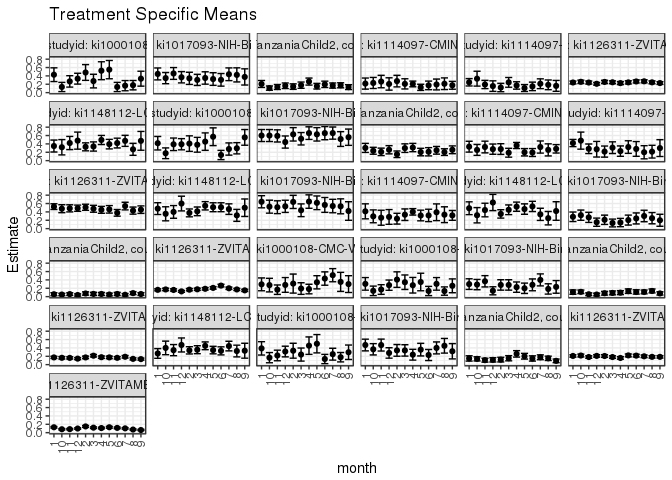

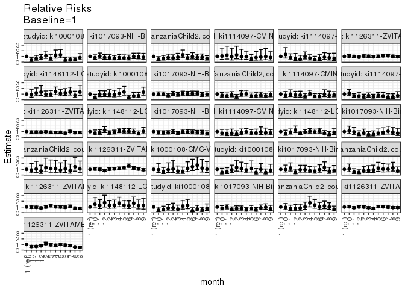

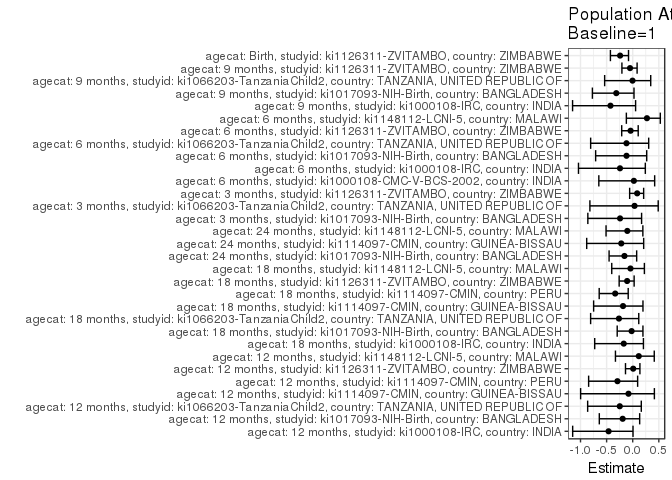

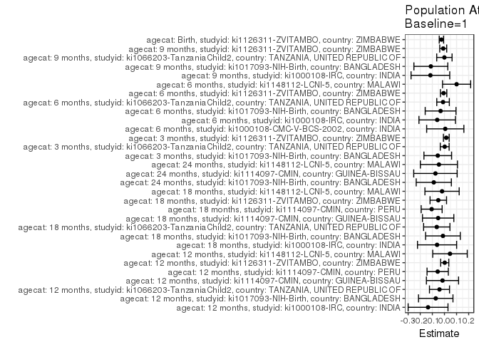

## Results Table

### Parameter: TSM

| agecat | studyid | country | intervention_level | baseline_level | estimate | ci_lower | ci_upper |
| --- | --- | --- | --- | --- | --- | --- | --- |
| Birth | ki1126311-ZVITAMBO | ZIMBABWE | 1 | NA | 0.1287202 | 0.1108156 | 0.1466249 |
| Birth | ki1126311-ZVITAMBO | ZIMBABWE | 2 | NA | 0.1486486 | 0.1269856 | 0.1703117 |
| Birth | ki1126311-ZVITAMBO | ZIMBABWE | 3 | NA | 0.1192982 | 0.1004816 | 0.1381149 |
| Birth | ki1126311-ZVITAMBO | ZIMBABWE | 4 | NA | 0.1102284 | 0.0908849 | 0.1295719 |
| Birth | ki1126311-ZVITAMBO | ZIMBABWE | 5 | NA | 0.1290000 | 0.1082237 | 0.1497763 |
| Birth | ki1126311-ZVITAMBO | ZIMBABWE | 6 | NA | 0.1139576 | 0.0954462 | 0.1324690 |
| Birth | ki1126311-ZVITAMBO | ZIMBABWE | 7 | NA | 0.1028912 | 0.0855263 | 0.1202560 |
| Birth | ki1126311-ZVITAMBO | ZIMBABWE | 8 | NA | 0.0742251 | 0.0595512 | 0.0888991 |
| Birth | ki1126311-ZVITAMBO | ZIMBABWE | 9 | NA | 0.0632140 | 0.0500509 | 0.0763771 |
| Birth | ki1126311-ZVITAMBO | ZIMBABWE | 10 | NA | 0.0815739 | 0.0649540 | 0.0981938 |
| Birth | ki1126311-ZVITAMBO | ZIMBABWE | 11 | NA | 0.0837743 | 0.0676487 | 0.0998998 |
| Birth | ki1126311-ZVITAMBO | ZIMBABWE | 12 | NA | 0.0988048 | 0.0822950 | 0.1153145 |
| 3 months | ki1017093-NIH-Birth | BANGLADESH | 1 | NA | 0.2833333 | 0.1692135 | 0.3974532 |
| 3 months | ki1017093-NIH-Birth | BANGLADESH | 2 | NA | 0.2115385 | 0.1004388 | 0.3226381 |
| 3 months | ki1017093-NIH-Birth | BANGLADESH | 3 | NA | 0.1346154 | 0.0417659 | 0.2274649 |
| 3 months | ki1017093-NIH-Birth | BANGLADESH | 4 | NA | 0.1458333 | 0.0459004 | 0.2457662 |
| 3 months | ki1017093-NIH-Birth | BANGLADESH | 5 | NA | 0.2045455 | 0.0852550 | 0.3238359 |
| 3 months | ki1017093-NIH-Birth | BANGLADESH | 6 | NA | 0.2439024 | 0.1123392 | 0.3754656 |
| 3 months | ki1017093-NIH-Birth | BANGLADESH | 7 | NA | 0.3023256 | 0.1649344 | 0.4397168 |
| 3 months | ki1017093-NIH-Birth | BANGLADESH | 8 | NA | 0.2500000 | 0.1156926 | 0.3843074 |
| 3 months | ki1017093-NIH-Birth | BANGLADESH | 9 | NA | 0.2000000 | 0.0567387 | 0.3432613 |
| 3 months | ki1017093-NIH-Birth | BANGLADESH | 10 | NA | 0.3214286 | 0.1990021 | 0.4438551 |
| 3 months | ki1017093-NIH-Birth | BANGLADESH | 11 | NA | 0.2692308 | 0.1485661 | 0.3898955 |
| 3 months | ki1017093-NIH-Birth | BANGLADESH | 12 | NA | 0.1538462 | 0.0556949 | 0.2519974 |
| 3 months | ki1066203-TanzaniaChild2 | TANZANIA, UNITED REPUBLIC OF | 1 | NA | 0.0576923 | 0.0210961 | 0.0942885 |
| 3 months | ki1066203-TanzaniaChild2 | TANZANIA, UNITED REPUBLIC OF | 2 | NA | 0.0755814 | 0.0360702 | 0.1150926 |
| 3 months | ki1066203-TanzaniaChild2 | TANZANIA, UNITED REPUBLIC OF | 3 | NA | 0.0654762 | 0.0280630 | 0.1028894 |
| 3 months | ki1066203-TanzaniaChild2 | TANZANIA, UNITED REPUBLIC OF | 4 | NA | 0.0639535 | 0.0273806 | 0.1005264 |
| 3 months | ki1066203-TanzaniaChild2 | TANZANIA, UNITED REPUBLIC OF | 5 | NA | 0.0505618 | 0.0183676 | 0.0827560 |
| 3 months | ki1066203-TanzaniaChild2 | TANZANIA, UNITED REPUBLIC OF | 6 | NA | 0.0632911 | 0.0253170 | 0.1012653 |

[output cut: 342 more lines]

### Parameter: E(Y)

| agecat | studyid | country | intervention_level | baseline_level | estimate | ci_lower | ci_upper |
| --- | --- | --- | --- | --- | --- | --- | --- |
| Birth | ki1126311-ZVITAMBO | ZIMBABWE | NA | NA | 0.1036581 | 0.1032510 | 0.1040652 |
| 3 months | ki1017093-NIH-Birth | BANGLADESH | NA | NA | 0.2280702 | 0.2230198 | 0.2331206 |
| 3 months | ki1066203-TanzaniaChild2 | TANZANIA, UNITED REPUBLIC OF | NA | NA | 0.0597731 | 0.0592665 | 0.0602797 |
| 3 months | ki1126311-ZVITAMBO | ZIMBABWE | NA | NA | 0.1780419 | 0.1773507 | 0.1787330 |
| 6 months | ki1000108-CMC-V-BCS-2002 | INDIA | NA | NA | 0.3008130 | 0.2898222 | 0.3118038 |
| 6 months | ki1000108-IRC | INDIA | NA | NA | 0.2457002 | 0.2370866 | 0.2543139 |
| 6 months | ki1017093-NIH-Birth | BANGLADESH | NA | NA | 0.2681564 | 0.2621062 | 0.2742066 |
| 6 months | ki1066203-TanzaniaChild2 | TANZANIA, UNITED REPUBLIC OF | NA | NA | 0.0970922 | 0.0959231 | 0.0982613 |
| 6 months | ki1126311-ZVITAMBO | ZIMBABWE | NA | NA | 0.1660829 | 0.1656082 | 0.1665575 |
| 6 months | ki1148112-LCNI-5 | MALAWI | NA | NA | 0.3682956 | 0.3645815 | 0.3720097 |
| 9 months | ki1000108-IRC | INDIA | NA | NA | 0.2727273 | 0.2629402 | 0.2825143 |
| 9 months | ki1017093-NIH-Birth | BANGLADESH | NA | NA | 0.3570020 | 0.3501502 | 0.3638537 |
| 9 months | ki1066203-TanzaniaChild2 | TANZANIA, UNITED REPUBLIC OF | NA | NA | 0.1482103 | 0.1462703 | 0.1501503 |
| 9 months | ki1126311-ZVITAMBO | ZIMBABWE | NA | NA | 0.1978840 | 0.1975016 | 0.1982664 |
| 12 months | ki1000108-IRC | INDIA | NA | NA | 0.2931034 | 0.2801170 | 0.3060899 |
| 12 months | ki1017093-NIH-Birth | BANGLADESH | NA | NA | 0.3747454 | 0.3699595 | 0.3795314 |
| 12 months | ki1066203-TanzaniaChild2 | TANZANIA, UNITED REPUBLIC OF | NA | NA | 0.1655125 | 0.1635117 | 0.1675133 |
| 12 months | ki1114097-CMIN | GUINEA-BISSAU | NA | NA | 0.2000000 | 0.1969381 | 0.2030619 |
| 12 months | ki1114097-CMIN | PERU | NA | NA | 0.1913478 | 0.1870150 | 0.1956805 |
| 12 months | ki1126311-ZVITAMBO | ZIMBABWE | NA | NA | 0.2442827 | 0.2438900 | 0.2446755 |
| 12 months | ki1148112-LCNI-5 | MALAWI | NA | NA | 0.3945687 | 0.3892249 | 0.3999125 |
| 18 months | ki1000108-IRC | INDIA | NA | NA | 0.3555556 | 0.3438060 | 0.3673051 |
| 18 months | ki1017093-NIH-Birth | BANGLADESH | NA | NA | 0.5874730 | 0.5815100 | 0.5934360 |
| 18 months | ki1066203-TanzaniaChild2 | TANZANIA, UNITED REPUBLIC OF | NA | NA | 0.2408163 | 0.2379712 | 0.2436614 |
| 18 months | ki1114097-CMIN | GUINEA-BISSAU | NA | NA | 0.2811671 | 0.2767295 | 0.2856048 |
| 18 months | ki1114097-CMIN | PERU | NA | NA | 0.3149284 | 0.3074519 | 0.3224050 |
| 18 months | ki1126311-ZVITAMBO | ZIMBABWE | NA | NA | 0.4756598 | 0.4736416 | 0.4776781 |
| 18 months | ki1148112-LCNI-5 | MALAWI | NA | NA | 0.4593103 | 0.4538738 | 0.4647468 |
| 24 months | ki1017093-NIH-Birth | BANGLADESH | NA | NA | 0.5547786 | 0.5482302 | 0.5613269 |
| 24 months | ki1114097-CMIN | GUINEA-BISSAU | NA | NA | 0.3393829 | 0.3348198 | 0.3439461 |
| 24 months | ki1148112-LCNI-5 | MALAWI | NA | NA | 0.4421416 | 0.4349284 | 0.4493549 |

### Parameter: RR

| agecat | studyid | country | intervention_level | baseline_level | estimate | ci_lower | ci_upper |
| --- | --- | --- | --- | --- | --- | --- | --- |
| Birth | ki1126311-ZVITAMBO | ZIMBABWE | 1 | 1 | 1.0000000 | 1.0000000 | 1.0000000 |
| Birth | ki1126311-ZVITAMBO | ZIMBABWE | 2 | 1 | 1.1548196 | 0.9441066 | 1.4125610 |
| Birth | ki1126311-ZVITAMBO | ZIMBABWE | 3 | 1 | 0.9268026 | 0.7510259 | 1.1437195 |
| Birth | ki1126311-ZVITAMBO | ZIMBABWE | 4 | 1 | 0.8563409 | 0.6845361 | 1.0712652 |
| Birth | ki1126311-ZVITAMBO | ZIMBABWE | 5 | 1 | 1.0021734 | 0.8100680 | 1.2398361 |
| Birth | ki1126311-ZVITAMBO | ZIMBABWE | 6 | 1 | 0.8853122 | 0.7148568 | 1.0964121 |
| Birth | ki1126311-ZVITAMBO | ZIMBABWE | 7 | 1 | 0.7993394 | 0.6423171 | 0.9947477 |
| Birth | ki1126311-ZVITAMBO | ZIMBABWE | 8 | 1 | 0.5766391 | 0.4528181 | 0.7343183 |
| Birth | ki1126311-ZVITAMBO | ZIMBABWE | 9 | 1 | 0.4910962 | 0.3823070 | 0.6308424 |
| Birth | ki1126311-ZVITAMBO | ZIMBABWE | 10 | 1 | 0.6337302 | 0.4951837 | 0.8110403 |
| Birth | ki1126311-ZVITAMBO | ZIMBABWE | 11 | 1 | 0.6508242 | 0.5132450 | 0.8252826 |
| Birth | ki1126311-ZVITAMBO | ZIMBABWE | 12 | 1 | 0.7675932 | 0.6176032 | 0.9540095 |
| 3 months | ki1017093-NIH-Birth | BANGLADESH | 1 | 1 | 1.0000000 | 1.0000000 | 1.0000000 |
| 3 months | ki1017093-NIH-Birth | BANGLADESH | 2 | 1 | 0.7466063 | 0.3851665 | 1.4472209 |
| 3 months | ki1017093-NIH-Birth | BANGLADESH | 3 | 1 | 0.4751131 | 0.2137535 | 1.0560411 |
| 3 months | ki1017093-NIH-Birth | BANGLADESH | 4 | 1 | 0.5147059 | 0.2324642 | 1.1396257 |
| 3 months | ki1017093-NIH-Birth | BANGLADESH | 5 | 1 | 0.7219251 | 0.3553689 | 1.4665773 |
| 3 months | ki1017093-NIH-Birth | BANGLADESH | 6 | 1 | 0.8608321 | 0.4390903 | 1.6876527 |
| 3 months | ki1017093-NIH-Birth | BANGLADESH | 7 | 1 | 1.0670315 | 0.5813696 | 1.9584033 |
| 3 months | ki1017093-NIH-Birth | BANGLADESH | 8 | 1 | 0.8823529 | 0.4508537 | 1.7268280 |
| 3 months | ki1017093-NIH-Birth | BANGLADESH | 9 | 1 | 0.7058824 | 0.3103399 | 1.6055619 |
| 3 months | ki1017093-NIH-Birth | BANGLADESH | 10 | 1 | 1.1344538 | 0.6516843 | 1.9748602 |
| 3 months | ki1017093-NIH-Birth | BANGLADESH | 11 | 1 | 0.9502262 | 0.5201541 | 1.7358892 |
| 3 months | ki1017093-NIH-Birth | BANGLADESH | 12 | 1 | 0.5429864 | 0.2553403 | 1.1546717 |
| 3 months | ki1066203-TanzaniaChild2 | TANZANIA, UNITED REPUBLIC OF | 1 | 1 | 1.0000000 | 1.0000000 | 1.0000000 |
| 3 months | ki1066203-TanzaniaChild2 | TANZANIA, UNITED REPUBLIC OF | 2 | 1 | 1.3100775 | 0.5758546 | 2.9804452 |
| 3 months | ki1066203-TanzaniaChild2 | TANZANIA, UNITED REPUBLIC OF | 3 | 1 | 1.1349206 | 0.4832690 | 2.6652750 |
| 3 months | ki1066203-TanzaniaChild2 | TANZANIA, UNITED REPUBLIC OF | 4 | 1 | 1.1085271 | 0.4718832 | 2.6041030 |
| 3 months | ki1066203-TanzaniaChild2 | TANZANIA, UNITED REPUBLIC OF | 5 | 1 | 0.8764045 | 0.3567548 | 2.1529772 |
| 3 months | ki1066203-TanzaniaChild2 | TANZANIA, UNITED REPUBLIC OF | 6 | 1 | 1.0970464 | 0.4581694 | 2.6267812 |

[output cut: 342 more lines]

### Parameter: PAR

| agecat | studyid | country | intervention_level | baseline_level | estimate | ci_lower | ci_upper |
| --- | --- | --- | --- | --- | --- | --- | --- |
| Birth | ki1126311-ZVITAMBO | ZIMBABWE | 1 | NA | -0.0250621 | -0.0429714 | -0.0071528 |
| 3 months | ki1017093-NIH-Birth | BANGLADESH | 1 | NA | -0.0552632 | -0.1694947 | 0.0589684 |
| 3 months | ki1066203-TanzaniaChild2 | TANZANIA, UNITED REPUBLIC OF | 1 | NA | 0.0020808 | -0.0345189 | 0.0386805 |
| 3 months | ki1126311-ZVITAMBO | ZIMBABWE | 1 | NA | 0.0151508 | -0.0086315 | 0.0389332 |
| 6 months | ki1000108-CMC-V-BCS-2002 | INDIA | 1 | NA | 0.0066954 | -0.1470624 | 0.1604531 |
| 6 months | ki1000108-IRC | INDIA | 1 | NA | -0.0598553 | -0.2107603 | 0.0910497 |
| 6 months | ki1017093-NIH-Birth | BANGLADESH | 1 | NA | -0.0318436 | -0.1591261 | 0.0954389 |
| 6 months | ki1066203-TanzaniaChild2 | TANZANIA, UNITED REPUBLIC OF | 1 | NA | -0.0116035 | -0.0635606 | 0.0403536 |
| 6 months | ki1126311-ZVITAMBO | ZIMBABWE | 1 | NA | -0.0068027 | -0.0329472 | 0.0193418 |
| 6 months | ki1148112-LCNI-5 | MALAWI | 1 | NA | 0.1004384 | -0.0156756 | 0.2165525 |
| 9 months | ki1000108-IRC | INDIA | 1 | NA | -0.1161616 | -0.2759041 | 0.0435809 |
| 9 months | ki1017093-NIH-Birth | BANGLADESH | 1 | NA | -0.1123858 | -0.2524263 | 0.0276547 |
| 9 months | ki1066203-TanzaniaChild2 | TANZANIA, UNITED REPUBLIC OF | 1 | NA | -0.0005500 | -0.0640026 | 0.0629026 |
| 9 months | ki1126311-ZVITAMBO | ZIMBABWE | 1 | NA | -0.0101784 | -0.0388726 | 0.0185158 |
| 12 months | ki1000108-IRC | INDIA | 1 | NA | -0.1354680 | -0.3001314 | 0.0291954 |
| 12 months | ki1017093-NIH-Birth | BANGLADESH | 1 | NA | -0.0720631 | -0.2144224 | 0.0702962 |
| 12 months | ki1066203-TanzaniaChild2 | TANZANIA, UNITED REPUBLIC OF | 1 | NA | -0.0410093 | -0.1237810 | 0.0417624 |
| 12 months | ki1114097-CMIN | GUINEA-BISSAU | 1 | NA | -0.0162162 | -0.1490032 | 0.1165708 |
| 12 months | ki1114097-CMIN | PERU | 1 | NA | -0.0559641 | -0.1438313 | 0.0319031 |
| 12 months | ki1126311-ZVITAMBO | ZIMBABWE | 1 | NA | 0.0022956 | -0.0313132 | 0.0359043 |
| 12 months | ki1148112-LCNI-5 | MALAWI | 1 | NA | 0.0457315 | -0.0969350 | 0.1883980 |
| 18 months | ki1000108-IRC | INDIA | 1 | NA | -0.0611111 | -0.2227837 | 0.1005615 |
| 18 months | ki1017093-NIH-Birth | BANGLADESH | 1 | NA | -0.0125270 | -0.1559414 | 0.1308874 |
| 18 months | ki1066203-TanzaniaChild2 | TANZANIA, UNITED REPUBLIC OF | 1 | NA | -0.0635315 | -0.1721929 | 0.0451299 |
| 18 months | ki1114097-CMIN | GUINEA-BISSAU | 1 | NA | -0.0521662 | -0.1817050 | 0.0773726 |
| 18 months | ki1114097-CMIN | PERU | 1 | NA | -0.1057065 | -0.1923150 | -0.0190980 |
| 18 months | ki1126311-ZVITAMBO | ZIMBABWE | 1 | NA | -0.0509102 | -0.1189773 | 0.0171569 |
| 18 months | ki1148112-LCNI-5 | MALAWI | 1 | NA | -0.0198563 | -0.1613837 | 0.1216711 |
| 24 months | ki1017093-NIH-Birth | BANGLADESH | 1 | NA | -0.0880786 | -0.2333066 | 0.0571494 |
| 24 months | ki1114097-CMIN | GUINEA-BISSAU | 1 | NA | -0.0744102 | -0.2538840 | 0.1050636 |
| 24 months | ki1148112-LCNI-5 | MALAWI | 1 | NA | -0.0456633 | -0.1989673 | 0.1076408 |

### Parameter: PAF

| agecat | studyid | country | intervention_level | baseline_level | estimate | ci_lower | ci_upper |
| --- | --- | --- | --- | --- | --- | --- | --- |
| Birth | ki1126311-ZVITAMBO | ZIMBABWE | 1 | NA | -0.2417770 | -0.4271742 | -0.0804638 |
| 3 months | ki1017093-NIH-Birth | BANGLADESH | 1 | NA | -0.2423077 | -0.8595879 | 0.1700697 |
| 3 months | ki1066203-TanzaniaChild2 | TANZANIA, UNITED REPUBLIC OF | 1 | NA | 0.0348119 | -0.8202217 | 0.4882008 |
| 3 months | ki1126311-ZVITAMBO | ZIMBABWE | 1 | NA | 0.0850970 | -0.0587134 | 0.2093728 |
| 6 months | ki1000108-CMC-V-BCS-2002 | INDIA | 1 | NA | 0.0222576 | -0.6490651 | 0.4202895 |
| 6 months | ki1000108-IRC | INDIA | 1 | NA | -0.2436111 | -1.0387353 | 0.2414078 |
| 6 months | ki1017093-NIH-Birth | BANGLADESH | 1 | NA | -0.1187500 | -0.7101953 | 0.2681528 |
| 6 months | ki1066203-TanzaniaChild2 | TANZANIA, UNITED REPUBLIC OF | 1 | NA | -0.1195100 | -0.8056612 | 0.3059037 |
| 6 months | ki1126311-ZVITAMBO | ZIMBABWE | 1 | NA | -0.0409597 | -0.2109067 | 0.1051357 |
| 6 months | ki1148112-LCNI-5 | MALAWI | 1 | NA | 0.2727115 | -0.1218241 | 0.5284924 |
| 9 months | ki1000108-IRC | INDIA | 1 | NA | -0.4259259 | -1.1519700 | 0.0551612 |
| 9 months | ki1017093-NIH-Birth | BANGLADESH | 1 | NA | -0.3148044 | -0.7723302 | 0.0246115 |
| 9 months | ki1066203-TanzaniaChild2 | TANZANIA, UNITED REPUBLIC OF | 1 | NA | -0.0037112 | -0.5376393 | 0.3448163 |
| 9 months | ki1126311-ZVITAMBO | ZIMBABWE | 1 | NA | -0.0514362 | -0.2069178 | 0.0840154 |
| 12 months | ki1000108-IRC | INDIA | 1 | NA | -0.4621849 | -1.1500771 | 0.0056242 |
| 12 months | ki1017093-NIH-Birth | BANGLADESH | 1 | NA | -0.1922988 | -0.6397976 | 0.1330781 |
| 12 months | ki1066203-TanzaniaChild2 | TANZANIA, UNITED REPUBLIC OF | 1 | NA | -0.2477715 | -0.8630477 | 0.1643082 |
| 12 months | ki1114097-CMIN | GUINEA-BISSAU | 1 | NA | -0.0810811 | -0.9979645 | 0.4150365 |
| 12 months | ki1114097-CMIN | PERU | 1 | NA | -0.2924731 | -0.8443671 | 0.0942764 |
| 12 months | ki1126311-ZVITAMBO | ZIMBABWE | 1 | NA | 0.0093972 | -0.1381961 | 0.1378516 |
| 12 months | ki1148112-LCNI-5 | MALAWI | 1 | NA | 0.1159025 | -0.3307289 | 0.4126313 |
| 18 months | ki1000108-IRC | INDIA | 1 | NA | -0.1718750 | -0.7280637 | 0.2053007 |
| 18 months | ki1017093-NIH-Birth | BANGLADESH | 1 | NA | -0.0213235 | -0.2971016 | 0.1958211 |
| 18 months | ki1066203-TanzaniaChild2 | TANZANIA, UNITED REPUBLIC OF | 1 | NA | -0.2638172 | -0.8062270 | 0.1157069 |
| 18 months | ki1114097-CMIN | GUINEA-BISSAU | 1 | NA | -0.1855346 | -0.7487525 | 0.1962886 |
| 18 months | ki1114097-CMIN | PERU | 1 | NA | -0.3356524 | -0.6420080 | -0.0864548 |
| 18 months | ki1126311-ZVITAMBO | ZIMBABWE | 1 | NA | -0.1070307 | -0.2598079 | 0.0272191 |
| 18 months | ki1148112-LCNI-5 | MALAWI | 1 | NA | -0.0432307 | -0.4017243 | 0.2235775 |
| 24 months | ki1017093-NIH-Birth | BANGLADESH | 1 | NA | -0.1587635 | -0.4525816 | 0.0756231 |
| 24 months | ki1114097-CMIN | GUINEA-BISSAU | 1 | NA | -0.2192513 | -0.8814327 | 0.2098714 |
| 24 months | ki1148112-LCNI-5 | MALAWI | 1 | NA | -0.1032774 | -0.5107921 | 0.1943159 |